# Homework #1

#### Question #6 (Simple-to-Complex)

Below I’ve provided code that plots two representations of the same data. For this question you can ignore the code itself and focus on its output.

As background, these data describe the behavior of male and female drivers exiting parking lots. Specifically, researchers timed the number of seconds it took for drivers to vacate their parking space upon entering their vehicle. They also recorded whether or not another vehicle was waiting to take the parking space.

In the space below the code chunk, write 1-2 sentences explaining which plot is simpler and whether the more complex representation of the data is necessary.

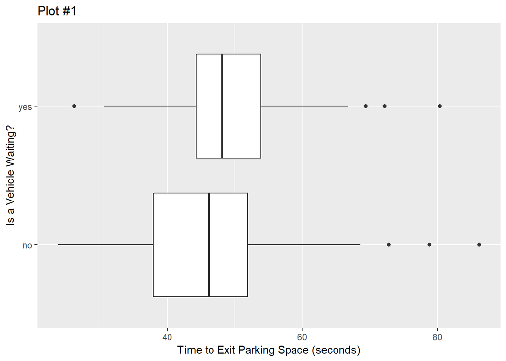

```r
parking <- read.csv('https://remiller1450.github.io/data/Parking.csv')

yvar <- parking[,colnames(parking) == 'time']

ggplot(data = parking, aes(x = waiting, y = time)) +
  geom_boxplot() +
  coord_flip() +
  labs(title = "Plot #1", x = "Is a Vehicle Waiting?", y = "Time to Exit Parking Space (seconds)")
```

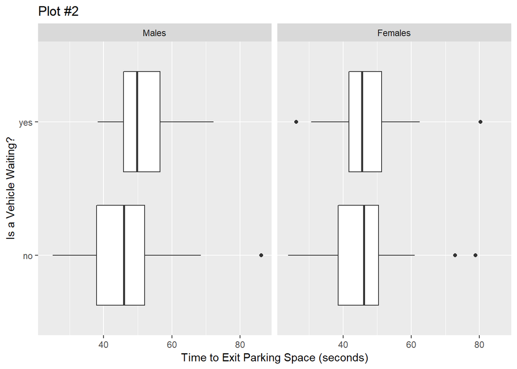

```r
levels(parking$gender) <- c("Males", "Females")
ggplot(data = parking, aes(x = waiting, y = time)) +
  geom_boxplot() +
  coord_flip() +
  facet_grid(~gender) +
  labs(title = "Plot #2", x = "Is a Vehicle Waiting?", y = "Time to Exit Parking Space (seconds)")
```

*indicate any help you received on this question here*